# Meeting Andrey & Peter

15 March, 2017

## Agenda

- Project proposals
- Heritability in GLMM
  - Binary traits in LDScore regression
  - Binary/count traits in GLMM

## Project proposals

The full list presnted to Hugo, Feb 2017

1. Truncated statistics for GxE test, #E > 2 (Zhu et al. 2015)
2. LD score regression applied to GxE
3. Gene Set x E
4. Common PCA: speed-up of LMMs, # effects > 1
5. Common PCA: genetic drift

Hugo voted for projects 4 & 5

## What is Common PCA used for?

Instrumental drift (batch) correction in LC/MS metabolomics data (Fernández-Albert et al. 2014)

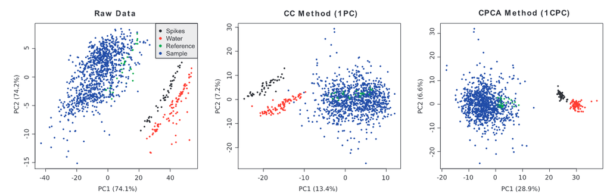

Ideas why that works

1. CPCA fits well to the definition of drift (instrumental) noise
2. The first component is often enough

## Common PCA: # LMM effects = 1

Model with a single random effect:

\(y = X \beta + g + e\)

\(\mbox{where } g \sim (0, \sigma_g^2 K) \mbox{ and } e \sim (0, \sigma_e^2 I)\)

\(\mbox{implying y } \sim (X \beta, V) = (X \beta, \sigma_g^2 K + \sigma_e^2 I)\)

The EVD trick (something standard for LMM in GWAS):

\(\sigma_g^2 K + \sigma_e^2 I = \sigma_g^2 U^T D U + \sigma_e^2 U^T I U = U^T [\sigma_g^2 D + \sigma_e^2 I] U\)

Speed-up on a tiny GWAS on the *A. thaliana* data set, N = 166 species, M = 20 SNPs:

- LMM: 23.7s
- EVD + LMM: 1.5s

## Common PCA: # LMM effects > 1

Model with *many* random effects:

\(y = X \beta + \sum_i{g_i} + e\)

\(\mbox{where } g_i \sim (0, \sigma_{i_g}^2 K_i) \mbox{ and } e \sim (0, \sigma_e^2 I)\)

\(\mbox{implying y } \sim (X \beta, V) = (X \beta, \sum_i{\sigma_{i_g}^2 K_i} + \sigma_e^2 I)\)

The Common PCA hypothesis:

\(H_{CPCA}: K_i = U^T D_i U\)

If CPCA exists (the ideal case):

\(\sum_i{\sigma_g^2 K_i} + \sigma_e^2 I = U^T [\sum_i{\sigma_g^2 D_i} + \sigma_e^2 I] U\)

## Common PCA: # LMM effects > 1

What are the use cases?

- Additive genetic + Dominance genetic (hardly the case in human genetics)
- Additive genetic + Family (pedigrees, especially animals like baboons)
- Additive genetic + Ancestry (Yu et al. 2006)

Is CPCA computable?

- The exact CPCA solution exists only if matrices \(K_i\) are [commuting](https://en.wikipedia.org/wiki/Commuting_matrices) (AB = BA)
- Needed to explore particular cases when CPCA works
  - low-rank of the second (family or ancestry) matrix

## Common PCA: genetic drift

(Galinsky et al. 2016)

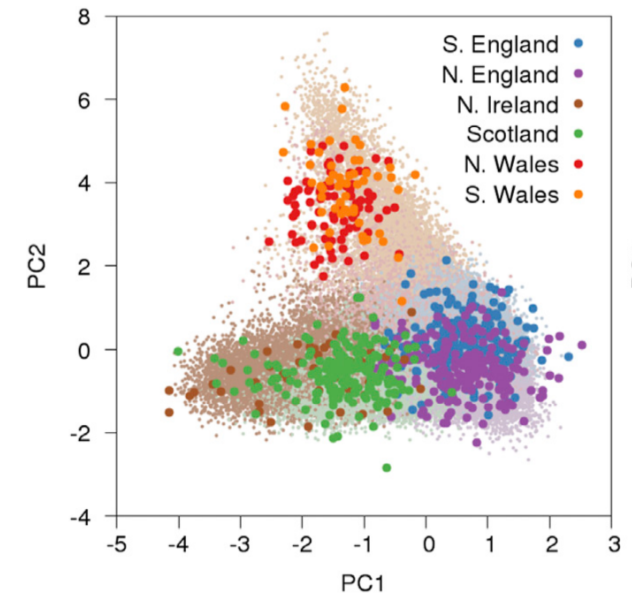

This application is similar to that of the long-term noise (drift)

## Heritability in LMM

Defition 1 in LMM (Bulik-Sullivan et al. 2015):

\(y = X \beta + e\)

\(\beta = argmax_{\alpha} Cor[y, X \alpha]\)

\(h^2_{snp} = \sum{\beta_j^2}\)

Defition 2 in LMM:

\(h^2 = \frac{\sigma^2_g}{\sigma^2_{total}}\)

## Heritability on observed and liability scales

On the observed scale:

\(y = \mu 1 + u + e\)

On the liability scale:

\(l = \mu 1 + g + e\)

Assumed as in (Dempster and Lerner 1950):

\(u = Const + bg = Const + cov(y, l) g = Const + zg\)

Result for both both REML (Lee et al. 2011) and LDscore reg. (Bulik-Sullivan et al. 2015) :

\(h^2_{obs_{cc}} = h^2_l \frac{z^2 P (1-P)}{K^2 (1 - K)^2}\)

## Heritability in GLMM

In animal breeding studies (Vazquez et al. 2009), (Koeck et al. 2010), a heritability approximation on the \(\eta\)-scale

1. Variance of a probit random variable: \(1\)
2. Variance of a logistic random variable: \(\pi^2/3\)

## References

Bulik-Sullivan B, Finucane HK, Anttila V, Gusev A, Day FR, Loh P-R, Duncan L, Perry JR, Patterson N, Robinson EB, others (2015) An atlas of genetic correlations across human diseases and traits.

Dempster ER, Lerner IM (1950) Heritability of threshold characters. Genetics 35:212.

Fernández-Albert F, Llorach R, Garcia-Aloy M, Ziyatdinov A, Andres-Lacueva C, Perera A (2014) Intensity drift removal in lc/ms metabolomics by common variance compensation. Bioinformatics 30:2899–2905.

Galinsky KJ, Loh P-R, Mallick S, Patterson NJ, Price AL (2016) Population structure of uk biobank and ancient eurasians reveals adaptation at genes influencing blood pressure. The American Journal of Human Genetics 99:1130–1139.

Koeck A, Heringstad B, Egger-Danner C, Fuerst C, Fuerst-Waltl B (2010) Comparison of different models for genetic analysis of clinical mastitis in austrian fleckvieh dual-purpose cows. Journal of dairy science 93:4351–4358.

Lee SH, Wray NR, Goddard ME, Visscher PM (2011) Estimating missing heritability for disease from genome-wide association studies. The American Journal of Human Genetics 88:294–305.

Vazquez A, Gianola D, Bates D, Weigel K, Heringstad B (2009) Assessment of poisson, logit, and linear models for genetic analysis of clinical mastitis in norwegian red cows. Journal of dairy science 92:739–748.

Yu J, Pressoir G, Briggs WH, Bi IV, Yamasaki M, Doebley JF, McMullen MD, Gaut BS, Nielsen DM, Holland JB, others (2006) A unified mixed-model method for association mapping that accounts for multiple levels of relatedness. Nature genetics 38:203–208.

Zhu X, Feng T, Tayo BO, Liang J, Young JH, Franceschini N, Smith JA, Yanek LR, Sun YV, Edwards TL, others (2015) Meta-analysis of correlated traits via summary statistics from gwass with an application in hypertension. The American Journal of Human Genetics 96:21–36.